# GH1033102 ML_Project

[figure not shown]

```python
from IPython.display import Image
Image(filename='C:/Users/darshan gangappa/Pictures/Screenshots/Screenshot 2024-09-24 185529.png')
```

**Introduction**

The target of the dataset is another aspect of the audiobook market, particularly, the likelihood of the customers’ repeat buying. It has customer data of aspects such as listening habits, buying behaviour, activity level and a need of help. Such information is useful for companies that are interested in customer retention, effectiveness of the marketing campaigns, and general UX.

Hence, the evaluation of the provided features which are the total time spent on listening, amount spent on purchases, and frequency of support, the dataset provides an understanding of what motivates the customers to build loyalty. The outcome is to use these findings to create forecast models to detect factors that may help determine whether a customer will return so that specific action can be taken to retain the customers.

This dataset proves to be invaluable for analyzing the audiobooks customer trends as it serves as the basis for evidence-based decision-making in an attempt at improving customer experience and business performance.

**IMPORTING MODLES**

```python
import pandas as pd
import numpy as np
import sklearn.model_selection
import sklearn.compose
import sklearn.preprocessing
import sklearn.decomposition
import imblearn.over_sampling
import sklearn.svm
import sklearn.metrics
from sklearn.neighbors import KNeighborsClassifier
from sklearn.metrics import accuracy_score
from sklearn.naive_bayes import GaussianNB
from sklearn.svm import SVC
from sklearn.tree import DecisionTreeClassifier
import matplotlib.pyplot as plt
from sklearn import tree
from sklearn.ensemble import RandomForestClassifier
from sklearn.preprocessing import LabelEncoder
from sklearn.model_selection import train_test_split
from sklearn.metrics import accuracy_score
from sklearn.model_selection import GridSearchCV as gscv
```

**Loading the DATASETS**

```python
df = pd.read_csv("C:/Users/darshan gangappa/Desktop/ML notes/Audiobooks_data.csv")

print(df.shape)

df.head()
```

```
(14084, 12)
```

|  | ID | Book Length(mins)_overall | Book length(mins)_avg | Price_overall | Price_avg | Review | Review 10/10 | Minutes Listened | comptetion | Supoort Request | Last Visited | Targets |
| --- | --- | --- | --- | --- | --- | --- | --- | --- | --- | --- | --- | --- |
| 0 | 994 | 1620.0 | 1620 | 19.73 | 19.73 | 1 | 10.00 | 0.99 | 1603.8 | 5 | 92 | 0 |
| 1 | 1143 | 2160.0 | 2160 | 5.33 | 5.33 | 0 | 8.91 | 0.00 | 0.0 | 0 | 0 | 0 |
| 2 | 2059 | 2160.0 | 2160 | 5.33 | 5.33 | 0 | 8.91 | 0.00 | 0.0 | 0 | 388 | 0 |
| 3 | 2882 | 1620.0 | 1620 | 5.96 | 5.96 | 0 | 8.91 | 0.42 | 680.4 | 1 | 129 | 0 |
| 4 | 3342 | 2160.0 | 2160 | 5.33 | 5.33 | 0 | 8.91 | 0.22 | 475.2 | 0 | 361 | 0 |

The take Dataset is cleaned so we are injection "Nan" values for the Dataset

```python
df = df.copy()

print("Before injecting NaN:")
display(df.isna().sum())
print()

for _ in range(1000):
    i = np.random.randint(0, df.shape[0])
    j = np.random.randint(0, df.shape[1])
    df.iloc[i, j] = None

print("After injecting NaN:")
display(df.isna().sum())

df.to_csv("data_with_NaN.csv", index=False)
print()

print(df.shape)
```

```
Before injecting NaN:
```

```
ID                           0
Book Length(mins)_overall    0
Book length(mins)_avg        0
Price_overall                0
Price_avg                    0
Review                       0
Review 10/10                 0
Minutes Listened             0
comptetion                   0
Supoort Request              0
Last Visited                 0
Targets                      0
dtype: int64
```

```
After injecting NaN:
```

```
ID                           99
Book Length(mins)_overall    78
Book length(mins)_avg        88
Price_overall                79
Price_avg                    89
Review                       82
Review 10/10                 89
Minutes Listened             93
comptetion                   94
Supoort Request              67
Last Visited                 58
Targets                      77
dtype: int64
```

```
(14084, 12)
```

In above step we are injecting the Nan values because the taken Dataset is clean.So in next step we will clean the Dataset

```python
df.isnull().sum().sum()
```

```
993
```

**Splitting the Dataset into Training and Testing Datasent**

```python
df_train, df_test = sklearn.model_selection.train_test_split(df)
print("df_train:", df_train.shape)
print("df_test:", df_test.shape)
```

```
df_train: (10563, 12)
df_test: (3521, 12)
```

**Data Extraction**

```python
df_train.dtypes
```

```
ID                           float64
Book Length(mins)_overall    float64
Book length(mins)_avg        float64
Price_overall                float64
Price_avg                    float64
Review                       float64
Review 10/10                 float64
Minutes Listened             float64
comptetion                   float64
Supoort Request              float64
Last Visited                 float64
Targets                      float64
dtype: object
```

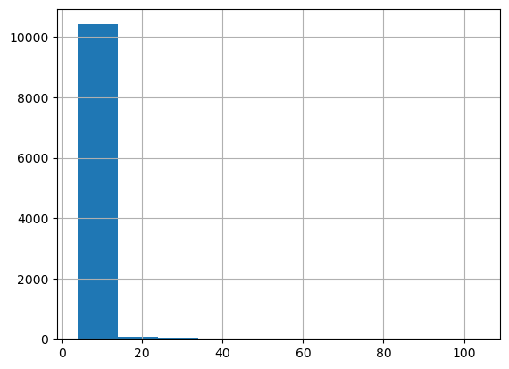

```python
df_train["Price_overall"].hist()
```

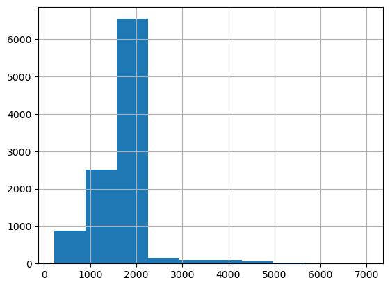

```python
df_train["Book length(mins)_avg"].hist()
```

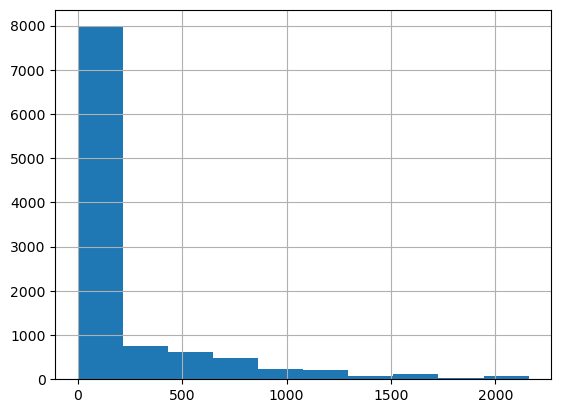

```python
df_train["comptetion"].hist()
```

**Removing Missing Values**

```python
df_train = df_train.replace("Nan", pd.NaT)
df_train = df_train.dropna()
print("df_train_cleaned:", df_train.shape)

df_test = df_test.replace(" Nan", pd.NaT)
df_test = df_test.dropna()
print("df_test_cleaned:", df_test.shape)
```

```
df_train_cleaned: (9849, 12)
df_test_cleaned: (3269, 12)
```

**Splitting Features and Target lable**

```python
x_train = df_train.drop(["Targets"], axis=1)
y_train = df_train["Targets"]
print("x_train:", x_train.shape)
print("y_train:", y_train.shape)

x_test = df_test.drop(["Targets"], axis=1)
y_test = df_test["Targets"]

print("x_test:", x_test.shape)
print("y_test:", y_test.shape)
```

```
x_train: (9849, 11)
y_train: (9849,)
x_test: (3269, 11)
y_test: (3269,)
```

**Feature Engineering**

One-hot Encodeing and Standadization

```python
x_train_df = pd.DataFrame(x_train)


numerical_attributes = x_train_df.select_dtypes(include=["int64", "float64"]).columns
categorical_attributes = x_train_df.select_dtypes(include="object").columns

ct = sklearn.compose.ColumnTransformer([
    ("standard_scaler", sklearn.preprocessing.StandardScaler(), numerical_attributes),
    ("one_hot_encoder", sklearn.preprocessing.OneHotEncoder(handle_unknown="ignore"), categorical_attributes)
])
ct = ct.fit(x_train)

x_train = ct.transform(x_train)
x_test = ct.transform(x_test)

print("x_train:", x_train.shape)
print("x_test:", x_test.shape)
```

```
x_train: (9849, 11)
x_test: (3269, 11)
```

**Over Sampling**

```python
sm = imblearn.over_sampling.SMOTE()
x_train, y_train = sm.fit_resample(x_train, y_train)
y_train.value_counts()
```

```
Targets
0.0    8285
1.0    8285
Name: count, dtype: int64
```

**Traning a Model**

**Logistic Regression**

```python
from sklearn.preprocessing import StandardScaler
from sklearn.linear_model import LogisticRegression
from sklearn.metrics import accuracy_score

log_reg = LogisticRegression(random_state=42)
log_reg.fit(x_train, y_train)

# Make predictions on the test set
y_pred = log_reg.predict(x_test)

# Evaluate the model
accuracy = accuracy_score(y_test, y_pred)

print(f"Accuracy: {accuracy}")
```

```
Accuracy: 0.8657081676353625
```

```python
svm = SVC(kernel='linear')
svm.fit(x_train, y_train)
y_pred = svm.predict(x_test)
accuracy_n = accuracy_score(y_test, y_pred)
print(f"Accuracy of SVM with linear kernel: {accuracy_n:.2f}")
```

```
Accuracy of SVM with linear kernel: 0.88
```

**Decision Tree**

```python
from sklearn.model_selection import train_test_split
from sklearn.metrics import classification_report, accuracy_score


dt_classifier = DecisionTreeClassifier(random_state=45,
                                             max_depth=10,
                                             min_samples_split=10,
                                             criterion='entropy')

# Train the model
dt_classifier.fit(x_train, y_train)

# Make predictions and evaluate the tuned model
y_pred = dt_classifier.predict(x_test)
accuracy_dt = accuracy_score(y_test, y_pred)

print("\n Decision Tree Model Accuracy:",accuracy_dt)
```

```
 Decision Tree Model Accuracy: 0.8507188742734781
```

**RandomForest Classifer**

```python
from sklearn.metrics import accuracy_score

# Initialize and train the RandomForestClassifier
rf_model = RandomForestClassifier(random_state=42, class_weight='balanced')
rf_model.fit(x_train, y_train)

y_pred = clf.predict(x_test)

# Evaluate the model
accuracy_r = accuracy_score(y_test, y_pred)

# Print the results
print(f"Accuracy: {accuracy_r * 100:.2f}%")
```

[output not shown]

**Model Evaluation**

```python
from sklearn.metrics import accuracy_score


y_pred = svm.predict(x_test)
accuracy_n = accuracy_score(y_test, y_pred)
print(f"Accuracy of SVM with linear kernel: {accuracy_n:.2f}")

y_pred = dt_classifier.predict(x_test)
accuracy_dt = accuracy_score(y_test, y_pred)
print("Decision Tree Model Accuracy:",accuracy_dt)

y_pred = log_reg.predict(x_test)
accuracy = accuracy_score(y_test, y_pred)
print(f"Accuracy of Logist Regresition model: {accuracy}")

y_pred = clf.predict(x_test)
accuracy_r = accuracy_score(y_test, y_pred)
print(f"Accuracy of Random forest Model is: {accuracy_r * 100:.2f}%")

models = {
    "Navie Bayes": accuracy_n,
    "Decision Tree": accuracy_dt,
    "Logistic Regression": accuracy_lr,
    "Random Forest": accuracy_r
}

best_model = max(models, key=models.get)
print(f"\nThe model with the highest accuracy score is: {best_model}")
```

[output not shown]

**Hypertuning Parameters Models**

Using Grid Search to optamize the performance:

```python
from sklearn.model_selection import GridSearchCV
from sklearn.naive_bayes import GaussianNB
from sklearn.preprocessing import StandardScaler

scaler = StandardScaler()
x_train_scaled = scaler.fit_transform(x_train)
x_test_scaled = scaler.transform(x_test)

# Define the parameter grid for Naive Bayes (var_smoothing)
param_grid_nb = {
    'var_smoothing': [1e-9, 1e-8, 1e-7, 1e-6, 1e-5, 1e-4, 1e-3]
}

# Initialize the Naive Bayes model
nb = GaussianNB()

# Perform Grid Search with cross-validation
grid_search_nb = GridSearchCV(estimator=nb, param_grid=param_grid_nb, cv=3, n_jobs=-1, verbose=2)
grid_search_nb.fit(x_train_scaled, y_train)

# Best hyperparameters and score
best_params_nb = grid_search_nb.best_params_
best_score_nb = grid_search_nb.best_score_

# Print the results
print(f"Best Parameters: {best_params_nb}")
print(f"Best Cross-Validation Score: {best_score_nb}")
```

```
Fitting 3 folds for each of 7 candidates, totalling 21 fits
Best Parameters: {'var_smoothing': 1e-09}
Best Cross-Validation Score: 0.7454438549363426
```